# SPET_Testing_Notebook

```python
#
```

```
Adwy   13/02/2022 20:31:16
```

### SPET Design testing Notebook

**SPET:** Single primer enrichment technology depends on the distance between the target SNP and the designed probes.

Core technology for Targeted Genotyping designs that comes with the Allegro NGS library Systems from Tecan Genomics.

[Read more here](https://lifesciences.tecan.com/allegro-targeted-genotyping-v2?p=tab--2)

### AllegroQC package

This Distribution Package aims at testing the success of the SPET design for Allegro products.

In this Notebook I list the commands used to run a test, and interpred the success of the target .. probe distances

**1) Clone the Repo**

```
 git clone https://github.com/AdWY21/allegro_QC.git
```

**2) Unzip the distribution Package**

```
 unzip SPET_QC.zip
```

**3) Navigate to the package folder**

```python
%%bash
cd SPET_QC/dist
ls -l
```

```
total 368348
-rwxr-xr-x 1 adwy adwy 377177200 Feb 12 19:20 allegro_QC
drwxrwxr-x 2 adwy adwy      4096 Feb 13 20:11 test
```

**4) Command structure**

```
./allegro_QC -start -qcPass <Name_for_Results_Directory> <path_to_target_SNPs_bed_file> <path_to_probe_bed_file>
```

**5) Provided here are; two test runs**

### (A) Testing a wrong design - design without any SPET success

```python
%%bash
cd SPET_QC/dist
QC_data="No_SPET.log"
./allegro_QC -start -qcPass No_SPET test/Test_targets.bed test/probesets_NO_SPET.bed | tee $QC_data
```

```
QC check for Allegro pipeline
-----------------------------

Description:
===========

script returns (1) stats summary (2) plots about the distance between designed SPET probes and target SNPs this can be used for fast check of arguments and
settings used to build the allegro designs
 the output is exported to a results directory tagged with date and time for job given


Developer:
**********

Script and standalone application were developed by Dr. Waly Adwy: https://www.linkedin.com/in/adwy/


welcome to allegro QC


inputs are target and probes bed files and a design ID


STATS                      # of SPET/SNP      #Drop  Drop%
-------------------------  ---------------  -------  -------
DesignID                   No_SPET
#Target SNPs               13332
Total # of SPET probes:    23579
#SPET probes on + Strand:  11739               1593  12.0 %
#SPET probes on - Strand:  11840               1492  11.0 %






summary for probe..SNP distances:
________________________________


```

[output cut: 16 more lines]

```
count  11840.000000
mean     126.859966
std       26.462106
min        1.000000
25%      123.000000
50%      131.000000
75%      140.000000
max      175.000000


exports:
-------

--------------------  --------------------------------------------------------------------------------------------------------------------------------------------------------------
results exported to:  /home/adwy/Backup_shared/Tecan/Checking_off_target_Allegro_Design/allegroQC/final_compile/test_automation/compiling/compressing/SPET_QC/dist/No_SPET_QCresults
```

```python
%%bash
ls -l SPET_QC/dist/No_SPET_QCresults
```

```
total 1976
-rw-rw-r-- 1 adwy adwy  16073 Feb 13 20:37 No_SPET_SPET_FW_plot.pdf
-rw-rw-r-- 1 adwy adwy 987833 Feb 13 20:37 No_SPET_SPET_FW.txt
-rw-rw-r-- 1 adwy adwy  16336 Feb 13 20:37 No_SPET_SPET_RV_plot.pdf
-rw-rw-r-- 1 adwy adwy 996216 Feb 13 20:37 No_SPET_SPET_RV.txt
```

#### This Table:

```
 STATS                      # of SPET/SNP      #Drop  Drop%
-------------------------  ---------------  -------  -------
DesignID                   No_SPET
#Target SNPs               13332
Total # of SPET probes:    23579
#SPET probes on + Strand:  11739               1593  12.0 %
#SPET probes on - Strand:  11840               1492  11.0 %
```

counts the probes covering target SNPs on both strands, and number of SNPs missed in probe coverages "drops"

Hitogram plots are found in the Results folder and exported as PDFs -

##### Plotting here again:

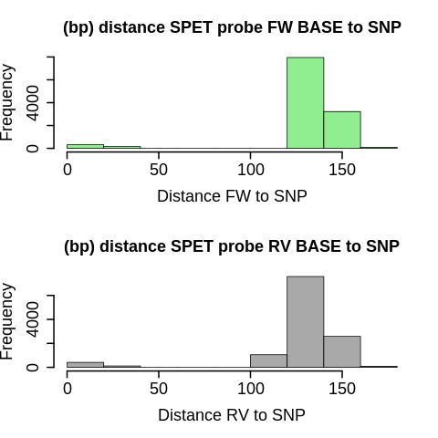

```
array([  1.        , 123.        , 131.        , 126.85996622,
       140.        , 175.        ])
```

```python
#
```

### (B) Testing Correct design - design with SPET success

```python
%%bash
cd SPET_QC/dist
QC_data="Correct_SPET.log"
./allegro_QC -start -qcPass correct_SPET test/Test_targets.bed test/probesets_corrected_SPET.bed | tee $QC_data
```

```
QC check for Allegro pipeline
-----------------------------

Description:
===========

script returns (1) stats summary (2) plots about the distance between designed SPET probes and target SNPs this can be used for fast check of arguments and
settings used to build the allegro designs
 the output is exported to a results directory tagged with date and time for job given


Developer:
**********

Script and standalone application were developed by Dr. Waly Adwy: https://www.linkedin.com/in/adwy/


welcome to allegro QC


inputs are target and probes bed files and a design ID


STATS                      # of SPET/SNP      #Drop  Drop%
-------------------------  ---------------  -------  -------
DesignID                   correct_SPET
#Target SNPs               13332
Total # of SPET probes:    21378
#SPET probes on + Strand:  10666               2666  20.0 %
#SPET probes on - Strand:  10712               2620  20.0 %






summary for probe..SNP distances:
________________________________


```

[output cut: 16 more lines]

```
count  10712.000000
mean      13.346807
std        8.430224
min        1.000000
25%        5.000000
50%       14.000000
75%       21.000000
max       55.000000


exports:
-------

--------------------  -------------------------------------------------------------------------------------------------------------------------------------------------------------------
results exported to:  /home/adwy/Backup_shared/Tecan/Checking_off_target_Allegro_Design/allegroQC/final_compile/test_automation/compiling/compressing/SPET_QC/dist/correct_SPET_QCresults
```

#### Comments

Notice the corrected average and 75% quartile distances between the target SNPs and covering probes, where max distance between SNP and target probe is not more than 55bp in all probe sets (sum= 21378)

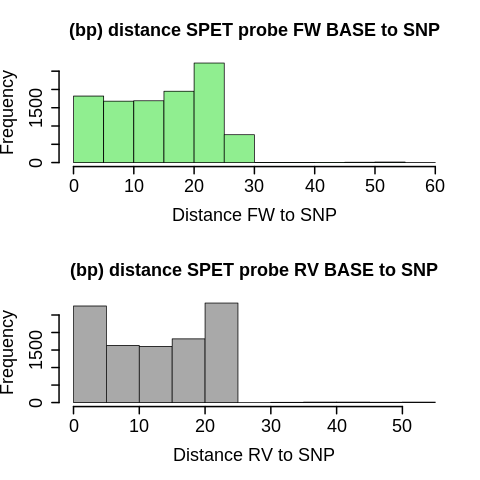

```
array([ 1.        ,  5.        , 14.        , 13.34680732, 21.        ,
       55.        ])
```

```python
#
```

##### Need help or support?

Reach out here: **waly.essam.adwy@gmail.com**